# Week 5 - Midterm Exam

Author: Laura Wooten

Last update: 06 May, 2025

1. load data
2. pData organized as [patients, variables] where tumor and normal sample id’s are columns 2,3
3. mrnaData organized as [genes, samples] where mrnaData[,1] is gene name, then [,2:104] tumor samples, and [,105:207] normal samples.

```r
mrnaData <- read.table("TCGA_BRCA_mRNA_expression.csv",header= T, sep = ",")
pData <- read.table("TCGA_BRCA_clinical_data.csv", header=T, sep=",")
protData <- read.table("TCGA_BRCA_RPPA_protein_expression.csv", header = T, sep = ",")
```

> 1. 10 points Investigate whether the ERBB2 (HER2) mRNA expression is significantly different between normal and tumor tissues. Perform both an unpaired t-test and a paired t-test. Clearly explain the results from each test and discuss which test is more appropriate for answering this question. Ensure that you state the null hypothesis clearly and indicate whether you accept or reject it based on the results obtained.
1. Create df for each outcome [sample, ERBB2].
2. H0 = no significant difference ERBB2 expression b/w tumor and normal samples.
3. Is data normalized, no -> pull samples for each outcome.
4. Perform t-test on sample data.

```r
# Partition data for ERBB2 with each outcome
tumor.erbb2 <- mrnaData[mrnaData$X=="ERBB2", pData$Sample_ID_Tumor]; rownames(tumor.erbb2) <- "ERBB2"
tumor.erbb2 <- t(tumor.erbb2)
normal.erbb2 <- mrnaData[mrnaData$X=="ERBB2", pData$Sample_ID_Normal]; rownames(normal.erbb2) <- "ERBB2"
normal.erbb2 <- t(normal.erbb2)

#check for normality
shapiro.test(tumor.erbb2)
```

```
    Shapiro-Wilk normality test

data:  tumor.erbb2
W = 0.37054, p-value < 2.2e-16
```

```r
shapiro.test(normal.erbb2)
```

```
    Shapiro-Wilk normality test

data:  normal.erbb2
W = 0.90465, p-value = 1.746e-06
```

p-value for each is <0.05, data is not normal -> perform t-tests on means of repeated samples.

```r
create_sample_means <- function(matrix_col, replicates, smpl.size){
  smpl.means <- numeric(replicates)
  for (i in 1:replicates){
    tmp.smpl <- sample(matrix_col[!is.na(matrix_col)], smpl.size, replace = T) #set to replace so that each sample is independent
    tmp.mu <- mean(tmp.smpl)
    smpl.means[i] <- tmp.mu
  }
  return(smpl.means)
}
```

```r
#Call function and perfrom t-tests.
t.1kmu <- create_sample_means(tumor.erbb2[1], 1000, 30)
n.1kmu <- create_sample_means(normal.erbb2[1], 1000, 30)

t.test(t.1kmu, n.1kmu, paired= T)
```

```
    Paired t-test

data:  t.1kmu and n.1kmu
t = 7.369, df = 999, p-value = 3.598e-13
alternative hypothesis: true mean difference is not equal to 0
95 percent confidence interval:
 277.4281 478.8129
sample estimates:
mean difference
       378.1205
```

```r
t.test(t.1kmu, n.1kmu)
```

```
    Welch Two Sample t-test

data:  t.1kmu and n.1kmu
t = 7.4066, df = 1997.8, p-value = 1.902e-13
alternative hypothesis: true difference in means is not equal to 0
95 percent confidence interval:
 277.9996 478.2414
sample estimates:
mean of x mean of y
 11089.76  10711.64
```

> 2. 20 points Analyze the correlation between ERBB2 (HER2) mRNA expression and RPPA protein levels in HER2-IHC negative patients. Calculate both the Pearson and Spearman correlation coefficients, along with their respective p-values, for ERBB2 mRNA and RPPA protein levels. Clearly explain the results from each correlation method and discuss which method is more appropriate for this analysis. Ensure you state the null hypothesis clearly and indicate whether you accept or reject it based on the results obtained.
1. I believe this questing is asking correlation between ERBB2 mRNA and ERBB2 RPPA protein levels (not ERBB2 mRNA with all PRRPA prot levels).
2. subset data - HER-IHC negative patients, Variables= X-ERBB2mRNA, Y-ERBB2prot, (protein data only looks at tumor samples).
3. H0 = There is no correlation between ERBB2 mRNA expression and PRRPA levels in HER2-IHC negative patients.

```r
#list of samples where her-ich == negative
negHER.smpls <- pData[pData$IHCHER2=="Negative" & !is.na(pData$IHCHER2),"Sample_ID_Tumor"]
#pull from mrna & prot df's
mrna_negHER <- mrnaData[mrnaData$X == "ERBB2", negHER.smpls]
prot_negHER <- protData[protData$X == "ERBB2", negHER.smpls]
rownames(mrna_negHER) <- "mrna_erbb2";rownames(prot_negHER) <- "prot_erbb2"

#merge
negHER_erbb2_df <- rbind(mrna_negHER, prot_negHER)

erbb2_pearson <- cor.test(as.numeric(negHER_erbb2_df[1,]), as.numeric(negHER_erbb2_df[2,]), method = "pearson")
#print result
print(paste("Pearson coefficient:", erbb2_pearson$estimate, "p-value:", erbb2_pearson$p.value))
```

```
[1] "Pearson coefficient: 0.412610494891634 p-value: 0.00290410453951045"
```

```r
erbb2_spearman <- cor.test(as.numeric(negHER_erbb2_df[1,]), as.numeric(negHER_erbb2_df[2,]), method = "spearman")
#print result
print(paste("Spearman coefficient:", erbb2_spearman$estimate, "p-value:", erbb2_spearman$p.value))
```

```
[1] "Spearman coefficient: 0.411860744297719 p-value: 0.00318428051379107"
```

```r
#Pearson's correlation assumes normal distribution, test each variable for normality
shap.mrna <- shapiro.test(as.numeric(negHER_erbb2_df[1,]))
shap.prot <- shapiro.test(as.numeric(negHER_erbb2_df[2,]))

print(paste("Shapiro-Wilk p-values for ERBB2 mRNA:", shap.mrna$p.value, "and ERBB2 RPPA:", shap.prot$p.value))
```

```
[1] "Shapiro-Wilk p-values for ERBB2 mRNA: 0.00105266014111268 and ERBB2 RPPA: 0.740262762811676"
```

**DISCUSS**  
Both the coefficient estimates and the p-values are very similar from both tests. The Pearson coefficient estimate represents the strength and direction of a linear relationship between the two variables, while the Spearman coefficient estimate represents the strength and direction of a consistent, unidirectional relationship between the two variables, regardless of whether the relationship is linear. We can see that the p-values for each are very similar at 0.0029 and 0.0032, both of which are less than 0.05. Therefore, we can reject the null hypothesis, which states there is no correlation between the two variables, and accept the alternate hypothesis that there is a significant relationship between the two variables. While I would expect there to be a predictive relationship between mRNA levels of a gene and protein levels of the same gene, it doesn’t necessarily mean it would be completely linear. There are many factors that can interfere with mRNA being translated and then post-translational modifications resulting in an active protein. While both methods work well for continuous data, Pearson’s correlation assumes normality, whereas Spearman’s correlation makes no assumptions about the data and tests whether there is a consistent increase or decrease based on the other variable, even if it’s not particularly linear. Even though the results were very similar between methods, to determine which test is preferred, I checked the normality of each variable and found that the Shapiro-Wilk p-value for the mRNA data was approximately 0.001, and the RPPA data p-value was 0.74. Now we’re in a situation where one set of data follows a normal distribution and the other does not. Since one set is not normal, I would still lean towards using the Spearman method, as the Pearson method assumes both sets of data are normal.

> 3. 20 points In breast cancer diagnostics, HER2 and ER statuses are critical biomarkers that influence treatment decisions. Oncologists are interested in the relationship between HER2-IHC and ER-IHC statuses in breast cancer patients. Please perform a test to determine if there is a significant association between HER2 and ER statuses in these patients. Ensure you state the null hypothesis clearly and indicate whether you accept or reject the null hypothesis based on the results obtained. (Only consider IHC positive and negative records, and remove NA, equivocal, and indeterminate records).
1. create vector for HER2-IHC, and ER-IHC.
2. Categorical variables - contingency tables.
3. H0 = There is no association between HER2 and ER statuses in breast cancer patients

```r
#Pull data from pData, filter for Positive and Negative only.
her2_er.df <- data.frame(
  her2= pData[!is.na(pData$IHCHER2) & pData$IHCHER2 %in% c("Positive", "Negative") &
                !is.na(pData$ER_Status_By_IHC) &
                pData$ER_Status_By_IHC %in% c("Positive", "Negative"), "IHCHER2"],
  er= pData[!is.na(pData$IHCHER2) & pData$IHCHER2 %in% c("Positive", "Negative") &
                !is.na(pData$ER_Status_By_IHC) &
                pData$ER_Status_By_IHC %in% c("Positive", "Negative"), "ER_Status_By_IHC"]
)

#preview
her2_er.df[1:5,]
```

|  | her2 | er |
| --- | --- | --- |
| 1 | Negative | Positive |
| 2 | Negative | Positive |
| 3 | Positive | Positive |
| 4 | Positive | Positive |
| 5 | Negative | Positive |

```r
#Create contigency table
her2_er.ct <- table(her2_er.df);her2_er.ct
```

```
          er
her2       Negative Positive
  Negative       11       39
  Positive        5       15
```

```r
##Pearson's chi square test want 5-10 obvserved and expected in each cell & contents should be uniform
#observations are >5 /cell, lets see expected
ch.f <- chisq.test(her2_er.ct, correct = F); ch.f$expected
```

```
          er
her2        Negative Positive
  Negative 11.428571 38.57143
  Positive  4.571429 15.42857
```

```r
ch.f
```

```
    Pearson's Chi-squared test

data:  her2_er.ct
X-squared = 0.072917, df = 1, p-value = 0.7871
```

```r
#expected values are not greater than 5 for each cell (so we want to keep correct=F for chisq.test), and contents are not uniform - compare to fishers
fisher.test(her2_er.ct,alternative = "two.sided")
```

```
    Fisher's Exact Test for Count Data

data:  her2_er.ct
p-value = 0.7628
alternative hypothesis: true odds ratio is not equal to 1
95 percent confidence interval:
 0.2221659 3.6534679
sample estimates:
odds ratio
 0.8482282
```

**DISCUSS**  
After segregating the data and constructing a contingency table of results, I was ready to proceed with selecting a significance test for two categorical variables. Based on the lecture notes, to use Pearson’s chi-square test the counts should be relatively even across cells of the contingency table, and the count of observations should be at least 5-10 in each cell. According to another article I found, expected counts (computed based on the assumption that there is no association between groups – so P(HER2-IHC, ER-IHC) = P(HER2-IHC) * P(ER-IHC)) should also be at least 5 in a minimum of 80% of cells [1]. Even though the counts did not look particularly uniform, I decided to see what the expected table would look like. One cell (HER2-IHC positive, ER-IHC negative) had an expected value of 4.57, so 25% of the table was <5. Therefore, I thought Fisher’s test would be more appropiate, however this method samples without replacement which results in dependent selections. This didn’t seem particularly right for this data, even though I have seen Fisher’s test used in the literature, so I decided to proceed with both the Pearson Chi-Square test (with correct =F to account for the cell with an expected value of <5) and the Fisher’s exact two-sample test which looks for a correlation in either direction. Comparing the results, the p-value for both tests is greater than 0.05, which means we can accept the null hypothesis that states the IHC status (presence) of the HER2 protein and ER protein are not correlated in the sample of breast cancer patients. The X-Squared value in the Pearson’s Chi-Squared test is also close to zero, which indicates there is not much difference between the observed and expected values, which supports no association. Looking at the confidence interval returned from Fisher’s test we can see that the range includes 1, and that our estimated odds ratio is 0.85. The odds ratio represents a measure of association between our groups, where a ratio of 1 means they are independent of each other. Having the confidence interval span across 1 suggests that the true underlying odds ratio of the population could be 1 (not that it would change, the population ratio is fixed). This further suggests that there is no significant association between the variables. Even though our estimated odds ratio is slightly less than 1, since the p-value is >0.05 it is not a significant difference.

> 4. 15 points Please construct a regression model with “fraction genome altered” as the input and “tumor mutation burden” (TMB_nonsynonymous) as the output. Calculate the 95% confidence interval for the regression coefficients. Explain the coefficients, their 95% CI, and the associated p-value for fraction genome altered. Additionally, explain the R-squared value and why it’s important for a regression model.
1. Independent continuous variable = fraction_genome_altered, dependent continuous variable = TMB_nonsynonymous
2. create vectors of variables.
3. construct linear model.
4. conf()

```r
Fga.Tmb.df <- data.frame(FGA= pData$Fraction_Genome_Altered, TMB= pData$TMB_nonsynonymous)
FgaTmb.lm <- lm(TMB~FGA, Fga.Tmb.df)
summary(FgaTmb.lm)
```

```
Call:
lm(formula = TMB ~ FGA, data = Fga.Tmb.df)

Residuals:
    Min      1Q  Median      3Q     Max
-1.7470 -0.9393 -0.4825  0.2519  6.4097

Coefficients:
            Estimate Std. Error t value Pr(>|t|)
(Intercept)   1.2363     0.2665   4.638 1.09e-05 ***
FGA           1.8378     0.7452   2.466   0.0154 *
---
Signif. codes:  0 ‘***’ 0.001 ‘**’ 0.01 ‘*’ 0.05 ‘.’ 0.1 ‘ ’ 1

Residual standard error: 1.525 on 98 degrees of freedom
  (3 observations deleted due to missingness)
Multiple R-squared:  0.05844,   Adjusted R-squared:  0.04883
F-statistic: 6.082 on 1 and 98 DF,  p-value: 0.01539
```

```r
ci.95 <- confint(FgaTmb.lm, level = 0.95); ci.95
```

```
                2.5 %   97.5 %
(Intercept) 0.7073285 1.765178
FGA         0.3589764 3.316547
```

**DISCUSS**  
If our output is tumor mutation burden, it means that the regression model aims to calculate, as our input changes, what happens to our output. Therefore, tumor mutation burden (TMB) is the dependent variable in this analysis, and fraction genome altered (FGA) is the independent variable.

The regression coefficients section of the results are really important to interpreting our model. The intercept estimate represents the expected value of our output (dependent variable) when the independent variable is zero. In other words, it represents the value of the tumor mutation burden where there is no association with fraction genome altered. The standard error, t value, and Pr(>|t|) measure the average deviations of observed points from the calculated regression line, the absolute value of the coefficient divided by its standard error, and the probability of obtaining a t-value the same or more extreme than our result, respectively. The higher the t-value, the greater the indication that the intercept is significantly greater than zero, and the lower the p-value the stronger the evidence against the null hypothesis (for this row it states the intercept is zero). Because the p-value 1.09e-5 is less that our cutoff, we can conclude that the intercept estimate is not due to chance and that when there is no alteration in the genome, the tumor mutation burden has a baseline of 1.2363.

Looking at the “FGA” row of the coefficients section, the estimate is equal to 1.8378 with a p-value of 0.0154. Since we are now looking at the coefficient of the independent variable, the estimate relates to the slope or rate of change per one measurement of FGA. This means that for each one-unit increase in the fraction of the genome that is altered, the Tumor Mutation Burden is expected to increase by approximately 1.8378 units. The p-value indicates that this relationship is statistically significant at the 5% significance level, meaning that there is strong evidence to suggest that FGA has a predictive relationship with TMB, which is our alternate hypothesis for this row. The 95% confidence interval for the coefficient of FGA ranges from 0.3590 to 3.3165. This interval suggests that we can be 95% confident of our model in predicting the true effect of FGA on TMB lying within this range. Since the confidence interval does not include zero, it also supports our conclusion that there is a significant positive relationship between the fraction of the genome that is altered and tumor mutation burden. Lastly the R-squared value represents the “explained” variance, or the proportion of the variance between the means of each variable. In this case R-squared is 0.05844, which means that only 5.84% of the variation seen is due to the relationship between the two variables. This is very small and indicates that there is a high level of variance in TMB that is unaccounted for.

> 5. 35 points Identify the genes most positively correlated with ERBB2 in normal and cancer samples. Write code to calculate the pearson correlation between ERBB2 and all genes in the mRNA expression table for normal and tumor samples separately. Save all correlation coefficients and p-values for each gene and perform multiple hypothesis testing correction for the p-values. Report the top 10 correlated genes in both the normal and tumor groups, including their correlation coefficients and p-adjust values.
1. partition data, normal/tumor w all mrna expression data & extract ERBB2 levels for each outcome.
2. Remember all data is continuous.
3. for each partitioned dataset:
- Compare ERBB2 row against every other row in df - use pearson correlation.
- Save correlation coeff and p-value to df/vector.

```r
#use genes as rownames
rownames(mrnaData) <- mrnaData[,1]
mrnaData <- mrnaData[,-1]
```

```r
#partition data by outcome - remove erbb2 as we will be comparing it to each row
tumor.mrna <- mrnaData[rownames(mrnaData)!="ERBB2",pData$Sample_ID_Tumor]
normal.mrna <- mrnaData[rownames(mrnaData)!="ERBB2",pData$Sample_ID_Normal]
#assign ERBB2 levels
tumor.erbb2 <- as.numeric(tumor.mrna["ERBB2",pData$Sample_ID_Tumor])
normal.erbb2 <- as.numeric(normal.mrna["ERBB2", pData$Sample_ID_Normal])

#zero_variance_genes <- apply(tumor.mrna, 1, function(gene) var(gene) == 0)
#sum(zero_variance_genes)

#use apply to calculate pearson corr for each gene in the mrna dfs
tumor.pearson <- apply(tumor.mrna, 1, function(gene) cor.test(gene, tumor.erbb2, method = "pearson"))
normal.pearson <- apply(normal.mrna, 1, function(gene) cor.test(gene, normal.erbb2, method = "pearson"))


#get gene name, correlation, p-value for each outcome
tumor.results.df <- data.frame(
  gene = names(tumor.pearson),
  corr = sapply(tumor.pearson, function(x) x$estimate),
  pvalue = sapply(tumor.pearson, function(x) x$p.value)
)
normal.results.df <- data.frame(
  gene = names(normal.pearson),
  corr = sapply(normal.pearson, function(x) x$estimate),
  pvalue = sapply(normal.pearson, function(x) x$p.value)
)
```

```r
#Perform multiple hypothesis testing correction - use Benjamini-Hochberg, less stringent than Bonferroni.
tumor.results.df$corrected_pvalue <- p.adjust(tumor.results.df$pvalue, method = "BH")
normal.results.df$corrected_pvalue <- p.adjust(normal.results.df$pvalue, method = "BH")

#Sort and slect the top 10 most positively correlated genes
tumor.top10 <- subset(tumor.results.df[order(tumor.results.df$corr, decreasing = T ), ][1:10,], select =-pvalue); tumor.top10
```

|  | gene | corr | corrected_pvalue |
| --- | --- | --- | --- |
| ERBB2IP.cor | ERBB2IP | 1.0000000 | 0.000000e+00 |
| AFF4.cor | AFF4 | 0.8846227 | 3.058252e-31 |
| SFRS12.cor | SFRS12 | 0.8830315 | 3.908666e-31 |
| AGGF1.cor | AGGF1 | 0.8784029 | 1.847048e-30 |
| UTP15.cor | UTP15 | 0.8597251 | 1.239842e-27 |
| PJA2.cor | PJA2 | 0.8500672 | 2.317684e-26 |
| PHAX.cor | PHAX | 0.8493142 | 2.508577e-26 |
| RBM27.cor | RBM27 | 0.8462644 | 5.574608e-26 |
| USP8.cor | USP8 | 0.8412255 | 2.212948e-25 |
| SMAD5.cor | SMAD5 | 0.8393882 | 3.392860e-25 |

```r
normal.top10 <- subset(normal.results.df[order(normal.results.df$corr, decreasing = T ), ][1:10,], select = -pvalue); normal.top10
```

|  | gene | corr | corrected_pvalue |
| --- | --- | --- | --- |
| ERBB2IP.cor | ERBB2IP | 1.0000000 | 0.000000e+00 |
| WAPAL.cor | WAPAL | 0.9748477 | 1.149776e-63 |
| PHF20L1.cor | PHF20L1 | 0.9739084 | 4.770608e-63 |
| AFF4.cor | AFF4 | 0.9719975 | 1.211776e-61 |
| C10orf18.cor | C10orf18 | 0.9678597 | 9.221428e-59 |
| C1orf124.cor | C1orf124 | 0.9673576 | 1.660617e-58 |
| C4orf41.cor | C4orf41 | 0.9663184 | 6.753072e-58 |
| SUZ12.cor | SUZ12 | 0.9658598 | 1.156658e-57 |
| LIN54.cor | LIN54 | 0.9655163 | 1.690142e-57 |
| SMARCAD1.cor | SMARCAD1 | 0.9635475 | 2.392214e-56 |

```r
#first entry is ERBB21P?? are there other ERBB2 genes?
other_ERBB <- grep("ERBB", rownames(tumor.mrna)); tumor.mrna[other_ERBB,1:3]
```

|  | TCGA_A7_A0CE_01 | TCGA_A7_A0CH_01 | TCGA_A7_A0D9_01 |
| --- | --- | --- | --- |
| ERBB2IP | 13705 | 7338 | 6830 |
| ERBB3 | 12489 | 22656 | 25185 |
| ERBB4 | 223 | 6497 | 10718 |

```r
NA
```

Confirm with linear model of ERBB2 vs ERBB2IP in tumor/normal tissues.

```r
oldpar <- par(mfrow = c(1, 2), cex.main = 0.7) # Set up a 1x2 plotting area

# Scatter plot
plot(as.numeric(tumor.mrna["ERBB2", ]), as.numeric(tumor.mrna["ERBB2IP", ]),
     xlab = "ERBB2 Expression",
     ylab = "ERBB2IP Expression",
     main = "ERBB2 vs ERBB2IP in tumor tissues",
     pch = 19, col = "blue")
abline(lm(as.numeric(tumor.mrna["ERBB2IP", ]) ~ as.numeric(tumor.mrna["ERBB2", ])), col = "red")
```

```r
plot(as.numeric(normal.mrna["ERBB2", ]), as.numeric(normal.mrna["ERBB2IP", ]),
     xlab = "ERBB2 Expression",
     ylab = "ERBB2IP Expression",
     main = "ERBB2 vs ERBB2IP in normal tissues",
     pch = 19, col = "blue")
abline(lm(as.numeric(normal.mrna["ERBB2IP", ]) ~ as.numeric(normal.mrna["ERBB2", ])), col = "red")
```

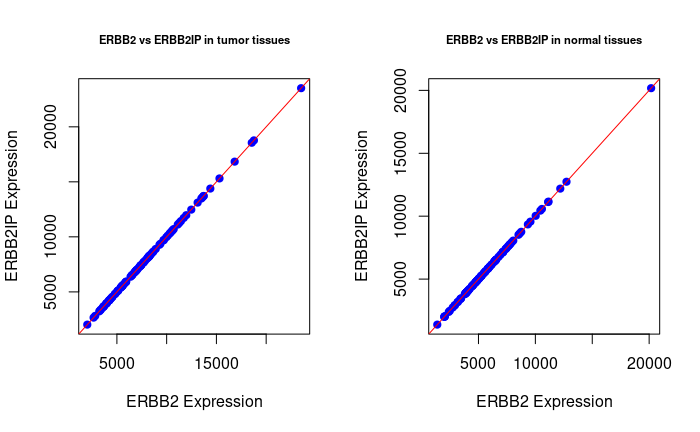

```r
par(oldpar)
```

```r
lm_model <- lm(as.numeric(tumor.mrna["ERBB2IP", ]) ~ as.numeric(tumor.mrna["ERBB2", ]))
summary(lm_model)
```

```
Call:
lm(formula = as.numeric(tumor.mrna["ERBB2IP", ]) ~ as.numeric(tumor.mrna["ERBB2",
    ]))

Residuals:
       Min         1Q     Median         3Q        Max
-8.342e-13 -1.675e-13 -7.480e-14  1.980e-14  8.837e-12

Coefficients:
                                   Estimate Std. Error   t value Pr(>|t|)
(Intercept)                       1.434e-12  2.092e-13 6.854e+00 5.79e-10 ***
as.numeric(tumor.mrna["ERBB2", ]) 1.000e+00  2.413e-17 4.144e+16  < 2e-16 ***
---
Signif. codes:  0 ‘***’ 0.001 ‘**’ 0.01 ‘*’ 0.05 ‘.’ 0.1 ‘ ’ 1

Residual standard error: 9.213e-13 on 101 degrees of freedom
Multiple R-squared:      1, Adjusted R-squared:      1
F-statistic: 1.718e+33 on 1 and 101 DF,  p-value: < 2.2e-16
```

```r
coef(lm_model)
```

```
                      (Intercept) as.numeric(tumor.mrna["ERBB2", ])
                     1.433843e-12                      1.000000e+00
```

**DISCUSS**  
In week 3, we extensively discussed the Bonferroni and Benjamini-Hochberg methods for multiple hypothesis testing correction. The Bonferroni method is more conservative and can increase the likelihood of rejecting significant values, especially in large datasets such as gene expression studies. While we are only looking at the top 10 correlated genes, either approach would likely result in the same genes. However, I decided to use the Benjamini-Hochberg method to correct for multiple hypothesis testing because it is less stringent and controls the false discovery rate more effectively.

While all the correlations are positive (as ERBB2 increases, so does the gene of interest), we observe that the correlations between ERBB2 expression and other gene expressions in normal tissues are stronger with lower p-values (higher levels of significance) compared to those in tumor samples. Also, the second and third highest correlated genes in normal samples are not present at all in the tumor samples. This could indicate that the regulatory mechanisms involving ERBB2 differ between normal and tumor tissues, potentially due to alterations in signaling pathways or gene expression regulation in cancerous cells.

**REFRENCES**  
[1] McHugh M. L. (2013). The chi-square test of independence. Biochemia medica, 23(2), 143–149. https://doi.org/10.11613/bm.2013.018  
[2] Jafari, M., & Ansari-Pour, N. (2019). Why, When and How to Adjust Your P Values?. Cell journal, 20(4), 604–607. https://doi.org/10.22074/cellj.2019.5992  
[3] National Center for Biotechnology Information. https://www.ncbi.nlm.nih.gov/gene/55914